# Data Translation Project

Group 7

March 17, 2022

## R Markdown

```r
library(tidyverse)
library(vtable)
library(lubridate)
library(fixest)
library(jtools)
library(car)
library(lmtest)
library(ggpubr)
library(effects)
library(haven)
```

```r
rawdata <- read_dta("./cps_00005.dta")

indnamelink <- read_csv("./indnames.csv")
rawlinkedup <- rawdata %>% left_join(indnamelink, by = "ind")
```

Important variables and their values:

covidunaw (Unable to work due to Covid): No = 1, Yes = 2

Employment status: Armed forces = 1 , At work = 10, has job not work last week = 12, Unemployed experienced worker = 21, unemployed new worker = 22, Not in labor force = 30-36

Sex: Male = 1, Female = 2

Race: White = 100, Black = 200, American Indian = 300, Asian/Pacific Islander = 650 (651 Asian Only 652 Pacific Islander Only). Discussion about multi race

marst (marital status): married spouse present = 1, married spouse absent = 2, separated = 3, divorced = 4, widowed = 5, single = 6

```r
rawlinkedup <- rawlinkedup %>% mutate(yearmonth = make_date(year = rawlinkedup$year, month = rawlinkedup$month))

fulldata <- rawlinkedup %>% mutate(aftercovid = ifelse(yearmonth > as_date("2020-03-01"),1,0))

fulldata <- fulldata %>% mutate(working = ifelse(empstat == 10,1,0))

fulldata <- fulldata %>% mutate(retail = indname == 'Retail Trade')

fulldata <- fulldata %>% mutate(male = sex == 1)

fulldata <- fulldata %>% mutate(young = age <= 41)

fulldata <- fulldata %>% mutate(earnweek = ifelse(earnweek > 9999, NA_real_, earnweek))

fulldata <- fulldata %>% mutate(marst = ifelse(marst > 8, NA_real_, marst))

fulldata <- fulldata %>% mutate(race = ifelse(race > 831, NA_real_, race))

fulldata <- fulldata %>% mutate(covidunaw = ifelse(covidunaw > 98, NA_real_, covidunaw))

fulldata <- fulldata %>% mutate(covidlook = ifelse(covidlook > 98, NA_real_, covidlook))
```

The above code is used to manipulate the data set in order to create variables for the models we’ll build. Specifically, we created a “yearmonth” variable to assign a time for each observation in a year-month format. We also use “mutate” to create a number of variables that we plan to use in our regression models in order to explain changes in employment and earnings before and after Covid.

We’d like to note that we turned the variable “age” into a binary variable (called *young*) to make it easier to work with in our models. We use the age 41 as a cutoff for young vs. old workers (i.e., age > 41 old workers, age =< 41 young workers). The assumption here is that if a worker is 41 or younger, then they are a millennial or Gen Z, which can both be considered groups of young people. The earning patterns between young and old workers differ, so in our models, we’d like to see how Covid affected the earnings of young people vs old people.

```r
model1 <- fulldata %>% feols(working ~ aftercovid:retail|yearmonth)
```

```
## NOTE: 2,001,596 observations removed because of NA values (RHS: 2,001,596).
```

```
## The variable 'aftercovid:retailTRUE' has been removed because of collinearity (see $collin.var).
```

```r
model2 <- lm(working ~ aftercovid*retail, data = fulldata)

export_summs(model1, model2, digits = 8, model.names = c("feols on working controlling for variation within time","lm on working with aftercovid*retail"))
```

|  | feols on working controlling for variation within time | lm on working with aftercovid*retail |
| --- | --- | --- |
| aftercovid:retailFALSE | 0.00985684 * |  |
|  | (0.00371794) |  |
| (Intercept) |  | 0.92399642 *** |
|  |  | (0.00033196) |
| aftercovid |  | -0.03711695 *** |
|  |  | (0.00044744) |
| retailTRUE |  | -0.00814858 *** |
|  |  | (0.00102690) |
| aftercovid:retailTRUE |  | -0.00119868 |
|  |  | (0.00137802) |
| N | 1976020 | 1976020 |
| R2 | 0.01287195 | 0.00399160 |
| *** p < 0.001; ** p < 0.01; * p < 0.05. |  |  |

The above code shows model 1, which is a fixed effects model showing employment trends while controlling for variation within time, and model 2, a multivariate regression model showing the difference in employment trends before and after Covid in the retail industry. The results of the regression models are shown in the table above.

```r
model3 <- lm(working ~ aftercovid*retail + young, data = fulldata)

model4 <- lm(working ~ aftercovid*retail + male, data = fulldata)

model5 <- lm(working ~ aftercovid*retail + young + male, data = fulldata)

export_summs(model2, model3, model4, model5, digits = 8, model.names = c("lm on working with aftercovid*retail","lm on working aftercovid*retail control for age","lm on working aftercovid*retail control for sex","lm on working aftercovid*retail control for age and sex"))
```

|  | lm on working with aftercovid*retail | lm on working aftercovid*retail control for age | lm on working aftercovid*retail control for sex | lm on working aftercovid*retail control for age and sex |
| --- | --- | --- | --- | --- |
| (Intercept) | 0.92399642 *** | 0.92760235 *** | 0.91633619 *** | 0.91993547 *** |
|  | (0.00033196) | (0.00038614) | (0.00039820) | (0.00044456) |
| aftercovid | -0.03711695 *** | -0.03713888 *** | -0.03714549 *** | -0.03716729 *** |
|  | (0.00044744) | (0.00044740) | (0.00044730) | (0.00044727) |
| retailTRUE | -0.00814858 *** | -0.00755775 *** | -0.00793756 *** | -0.00734961 *** |
|  | (0.00102690) | (0.00102732) | (0.00102661) | (0.00102703) |
| aftercovid:retailTRUE | -0.00119868 | -0.00114397 | -0.00125319 | -0.00119866 |
|  | (0.00137802) | (0.00137790) | (0.00137760) | (0.00137748) |
| youngTRUE |  | -0.00771355 *** |  | -0.00767929 *** |
|  |  | (0.00042202) |  | (0.00042189) |
| maleTRUE |  |  | 0.01466383 *** | 0.01464592 *** |
|  |  |  | (0.00042128) | (0.00042125) |
| N | 1976020 | 1976020 | 1976020 | 1976020 |
| R2 | 0.00399160 | 0.00415995 | 0.00460191 | 0.00476877 |
| *** p < 0.001; ** p < 0.01; * p < 0.05. |  |  |  |  |

```r
model6 <- lm(earnweek ~ aftercovid*young, data = fulldata)

model6youngbinary <- lm(earnweek ~ aftercovid*young, data = fulldata)

model7 <- lm(earnweek ~ aftercovid*male, data = fulldata)

export_summs(model6, model7, digits = 8, model.names = c("lm on earnweek with aftercovid*age","lm on earnweek with aftercovid*male"))
```

|  | lm on earnweek with aftercovid*age | lm on earnweek with aftercovid*male |
| --- | --- | --- |
| (Intercept) | 1125.13386948 *** | 872.57902562 *** |
|  | (2.29425474) | (2.31177004) |
| aftercovid | 78.02913334 *** | 79.77013802 *** |
|  | (3.10103696) | (3.13432143) |
| youngTRUE | -226.56352771 *** |  |
|  | (3.25963418) |  |
| aftercovid:youngTRUE | -7.93976095 |  |
|  | (4.41125661) |  |
| maleTRUE |  | 276.35298908 *** |
|  |  | (3.24429295) |
| aftercovid:maleTRUE |  | -12.06334705 ** |
|  |  | (4.39068637) |
| N | 422727 | 422727 |
| R2 | 0.02805950 | 0.03733606 |
| *** p < 0.001; ** p < 0.01; * p < 0.05. |  |  |

Model 3: a multivariate regression model showing the difference in employment trends before and after Covid in the retail industry controlling for age.

Model 4: a multivariate regression model showing the difference in employment trends before and after Covid in the retail industry controlling for sex.

Model 5: a multivariate regression model showing the difference in employment trends before and after Covid in the retail industry controlling for age and sex.

Model 6: a multivariate regression model showing the difference in earning trends by age before and after Covid.

Model 7: a multivariate regression model showing the difference in earning trends by sex before and after Covid.

The results of the regression models are shown in the tables above.

```r
bptest(model2)
```

```
##
##  studentized Breusch-Pagan test
##
## data:  model2
## BP = 8067, df = 3, p-value < 2.2e-16
```

```r
bptest(model3)
```

```
##
##  studentized Breusch-Pagan test
##
## data:  model3
## BP = 8396, df = 4, p-value < 2.2e-16
```

```r
bptest(model4)
```

```
##
##  studentized Breusch-Pagan test
##
## data:  model4
## BP = 9240.2, df = 4, p-value < 2.2e-16
```

```r
bptest(model5)
```

```
##
##  studentized Breusch-Pagan test
##
## data:  model5
## BP = 9564.4, df = 5, p-value < 2.2e-16
```

```r
bptest(model6)
```

```
##
##  studentized Breusch-Pagan test
##
## data:  model6
## BP = 2941.9, df = 3, p-value < 2.2e-16
```

```r
bptest(model7)
```

```
##
##  studentized Breusch-Pagan test
##
## data:  model7
## BP = 4351, df = 3, p-value < 2.2e-16
```

```r
linearHypothesis(model2,c("aftercovid=0","retailTRUE=0","aftercovid:retailTRUE=0"))
```

```
## Linear hypothesis test
##
## Hypothesis:
## aftercovid = 0
## retailTRUE = 0
## aftercovid:retailTRUE = 0
##
## Model 1: restricted model
## Model 2: working ~ aftercovid * retail
##
##    Res.Df    RSS Df Sum of Sq      F    Pr(>F)
## 1 1976019 173697
## 2 1976016 173004  3    693.33 2639.7 < 2.2e-16 ***
## ---
## Signif. codes:  0 '***' 0.001 '**' 0.01 '*' 0.05 '.' 0.1 ' ' 1
```

```r
linearHypothesis(model3,c("aftercovid=0","retailTRUE=0","aftercovid:retailTRUE=0","youngTRUE=0"))
```

```
## Linear hypothesis test
##
## Hypothesis:
## aftercovid = 0
## retailTRUE = 0
## aftercovid:retailTRUE = 0
## youngTRUE = 0
##
## Model 1: restricted model
## Model 2: working ~ aftercovid * retail + young
##
##    Res.Df    RSS Df Sum of Sq      F    Pr(>F)
## 1 1976019 173697
## 2 1976015 172975  4    722.57 2063.6 < 2.2e-16 ***
## ---
## Signif. codes:  0 '***' 0.001 '**' 0.01 '*' 0.05 '.' 0.1 ' ' 1
```

```r
linearHypothesis(model4,c("aftercovid=0","retailTRUE=0","aftercovid:retailTRUE=0","maleTRUE=0"))
```

```
## Linear hypothesis test
##
## Hypothesis:
## aftercovid = 0
## retailTRUE = 0
## aftercovid:retailTRUE = 0
## maleTRUE = 0
##
## Model 1: restricted model
## Model 2: working ~ aftercovid * retail + male
##
##    Res.Df    RSS Df Sum of Sq      F    Pr(>F)
## 1 1976019 173697
## 2 1976015 172898  4    799.34 2283.9 < 2.2e-16 ***
## ---
## Signif. codes:  0 '***' 0.001 '**' 0.01 '*' 0.05 '.' 0.1 ' ' 1
```

```r
linearHypothesis(model5,c("aftercovid=0","retailTRUE=0","aftercovid:retailTRUE=0","youngTRUE=0","maleTRUE=0"))
```

```
## Linear hypothesis test
##
## Hypothesis:
## aftercovid = 0
## retailTRUE = 0
## aftercovid:retailTRUE = 0
## youngTRUE = 0
## maleTRUE = 0
##
## Model 1: restricted model
## Model 2: working ~ aftercovid * retail + young + male
##
##    Res.Df    RSS Df Sum of Sq      F    Pr(>F)
## 1 1976019 173697
## 2 1976014 172869  5    828.32 1893.7 < 2.2e-16 ***
## ---
## Signif. codes:  0 '***' 0.001 '**' 0.01 '*' 0.05 '.' 0.1 ' ' 1
```

```r
linearHypothesis(model6, c("aftercovid=0","youngTRUE=0","aftercovid:youngTRUE=0"))
```

```
## Linear hypothesis test
##
## Hypothesis:
## aftercovid = 0
## youngTRUE = 0
## aftercovid:youngTRUE = 0
##
## Model 1: restricted model
## Model 2: earnweek ~ aftercovid * young
##
##   Res.Df        RSS Df  Sum of Sq      F    Pr(>F)
## 1 422726 2.2168e+11
## 2 422723 2.1546e+11  3 6220114505 4067.9 < 2.2e-16 ***
## ---
## Signif. codes:  0 '***' 0.001 '**' 0.01 '*' 0.05 '.' 0.1 ' ' 1
```

```r
linearHypothesis(model7,c("aftercovid=0","maleTRUE=0","aftercovid:maleTRUE=0"))
```

```
## Linear hypothesis test
##
## Hypothesis:
## aftercovid = 0
## maleTRUE = 0
## aftercovid:maleTRUE = 0
##
## Model 1: restricted model
## Model 2: earnweek ~ aftercovid * male
##
##   Res.Df        RSS Df  Sum of Sq    F    Pr(>F)
## 1 422726 2.2168e+11
## 2 422723 2.1340e+11  3 8276503795 5465 < 2.2e-16 ***
## ---
## Signif. codes:  0 '***' 0.001 '**' 0.01 '*' 0.05 '.' 0.1 ' ' 1
```

We use the Breusch-Pagan test above to check for Heteroscedasticity. The p-values here are far below 0.05, so we reject the null for the Breusch-Pagan test which is that the variance of the residuals is constant. Heteroscedasticity is present so we need robust standard errors. Additionally, the results for the hypothesis testing are statistically significant so we can reject the null.

```r
export_summs(model1, model2, digits = 8, model.names = c("feols on working controlling for variation withing time","lm on working with aftercovid*retail"), robust = TRUE, error_format = "[{conf.low}, {conf.high}], ({std.error})")
```

|  | feols on working controlling for variation withing time | lm on working with aftercovid*retail |
| --- | --- | --- |
| aftercovid:retailFALSE | 0.00985684 * |  |
|  | [0.00230902, 0.01740466], (0.00371794) |  |
| (Intercept) |  | 0.92399642 *** |
|  |  | [0.92341370, 0.92457913], (0.00029731) |
| aftercovid |  | -0.03711695 *** |
|  |  | [-0.03797470, -0.03625920], (0.00043764) |
| retailTRUE |  | -0.00814858 *** |
|  |  | [-0.01002820, -0.00626897], (0.00095901) |
| aftercovid:retailTRUE |  | -0.00119868 |
|  |  | [-0.00393482, 0.00153747], (0.00139602) |
| N | 1976020 | 1976020 |
| R2 | 0.01287195 | 0.00399160 |
| Standard errors are heteroskedasticity robust. *** p < 0.001; ** p < 0.01; * p < 0.05. |  |  |

```r
export_summs(model2, model3, model4, model5, digits = 8, model.names = c("lm on working with aftercovid*retail","lm on working aftercovid*retail control for age","lm on working aftercovid*retail control for sex","lm on working aftercovid*retail control for age and sex"), robust = TRUE, error_format = "[{conf.low}, {conf.high}], ({std.error})")
```

|  | lm on working with aftercovid*retail | lm on working aftercovid*retail control for age | lm on working aftercovid*retail control for sex | lm on working aftercovid*retail control for age and sex |
| --- | --- | --- | --- | --- |
| (Intercept) | 0.92399642 *** | 0.92760235 *** | 0.91633619 *** | 0.91993547 *** |
|  | [0.92341370, 0.92457913], (0.00029731) | [0.92690837, 0.92829633], (0.00035408) | [0.91560030, 0.91707209], (0.00037546) | [0.91910906, 0.92076187], (0.00042164) |
| aftercovid | -0.03711695 *** | -0.03713888 *** | -0.03714549 *** | -0.03716729 *** |
|  | [-0.03797470, -0.03625920], (0.00043764) | [-0.03799660, -0.03628116], (0.00043762) | [-0.03800308, -0.03628790], (0.00043756) | [-0.03802485, -0.03630972], (0.00043754) |
| retailTRUE | -0.00814858 *** | -0.00755775 *** | -0.00793756 *** | -0.00734961 *** |
|  | [-0.01002820, -0.00626897], (0.00095901) | [-0.00943696, -0.00567855], (0.00095880) | [-0.00981548, -0.00605963], (0.00095814) | [-0.00922711, -0.00547210], (0.00095793) |
| aftercovid:retailTRUE | -0.00119868 | -0.00114397 | -0.00125319 | -0.00119866 |
|  | [-0.00393482, 0.00153747], (0.00139602) | [-0.00387942, 0.00159148], (0.00139566) | [-0.00398730, 0.00148092], (0.00139498) | [-0.00393206, 0.00153474], (0.00139462) |
| youngTRUE |  | -0.00771355 *** |  | -0.00767929 *** |
|  |  | [-0.00854155, -0.00688555], (0.00042246) |  | [-0.00850703, -0.00685155], (0.00042232) |
| maleTRUE |  |  | 0.01466383 *** | 0.01464592 *** |
|  |  |  | [0.01383580, 0.01549185], (0.00042247) | [0.01381797, 0.01547387], (0.00042243) |
| N | 1976020 | 1976020 | 1976020 | 1976020 |
| R2 | 0.00399160 | 0.00415995 | 0.00460191 | 0.00476877 |
| Standard errors are heteroskedasticity robust. *** p < 0.001; ** p < 0.01; * p < 0.05. |  |  |  |  |

```r
export_summs(model6, model7, digits = 8, model.names = c("lm on earnweek with aftercovid*age","lm on earnweek with aftercovid*male"), robust = TRUE, error_format = "[{conf.low}, {conf.high}], ({std.error})")
```

|  | lm on earnweek with aftercovid*age | lm on earnweek with aftercovid*male |
| --- | --- | --- |
| (Intercept) | 1125.13386948 *** | 872.57902562 *** |
|  | [1120.41069860, 1129.85704037], (2.40981844) | [868.52901367, 876.62903756], (2.06636468) |
| aftercovid | 78.02913334 *** | 79.77013802 *** |
|  | [71.58948984, 84.46877685], (3.28558337) | [74.15993144, 85.38034461], (2.86239470) |
| youngTRUE | -226.56352771 *** |  |
|  | [-232.85423588, -220.27281954], (3.20959477) |  |
| aftercovid:youngTRUE | -7.93976095 |  |
|  | [-16.55236956, 0.67284767], (4.39425623) |  |
| maleTRUE |  | 276.35298908 *** |
|  |  | [270.11055087, 282.59542729], (3.18496686) |
| aftercovid:maleTRUE |  | -12.06334705 ** |
|  |  | [-20.62062904, -3.50606505], (4.36602793) |
| N | 422727 | 422727 |
| R2 | 0.02805950 | 0.03733606 |
| Standard errors are heteroskedasticity robust. *** p < 0.001; ** p < 0.01; * p < 0.05. |  |  |

We present the results of our models in the tables above again; however, because we found that heteroscedasticity is present, we ensure this time around that the standard errors are heteroskedasticity robust.

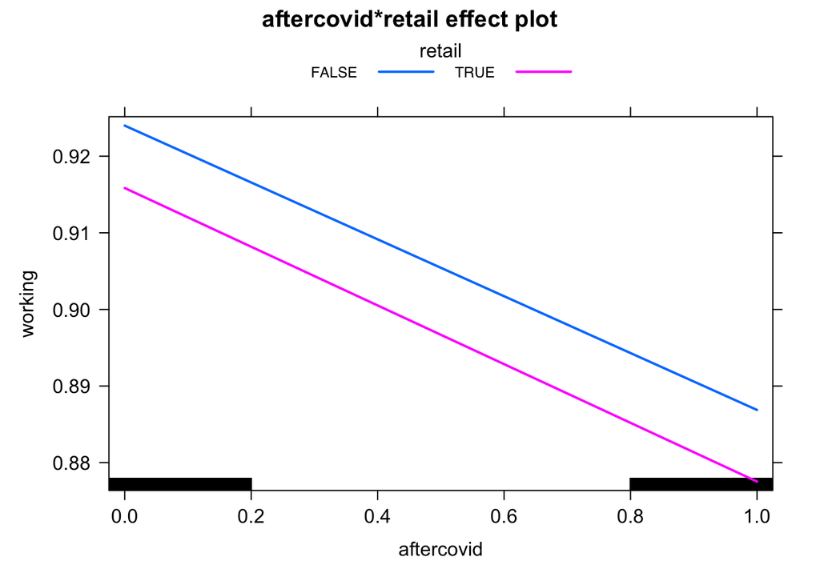

```r
model2effect <- effect('aftercovid*retail', model2, se= TRUE)
plot(model2effect, multiline = TRUE)
```

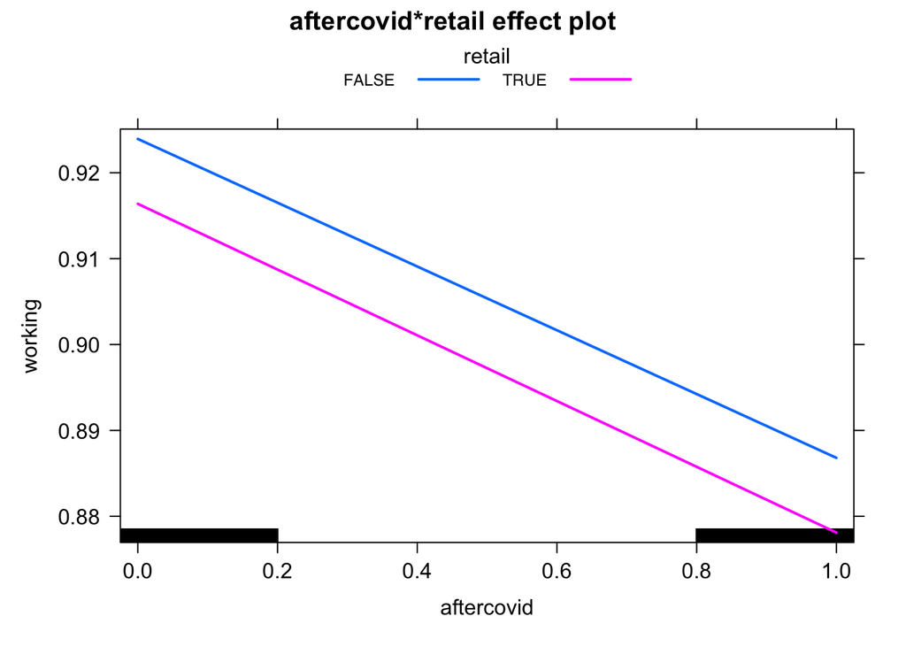

```r
model3effect <- effect('aftercovid*retail', model3, se= TRUE)
plot(model3effect, multiline = TRUE)
```

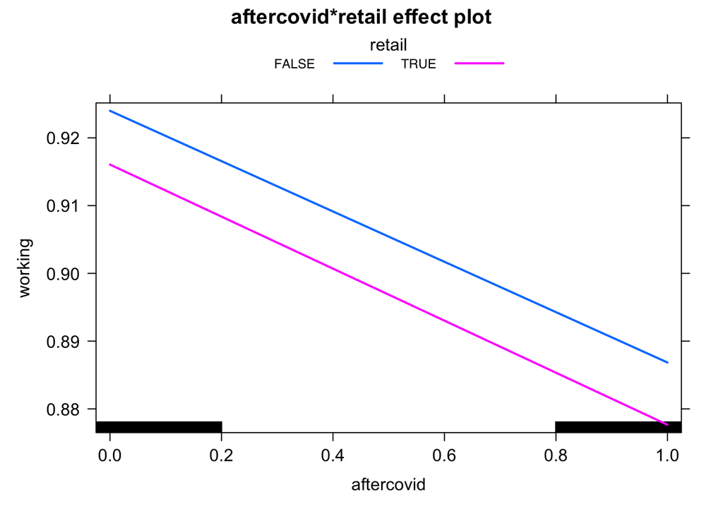

```r
model4effect <- effect('aftercovid*retail', model4, se= TRUE)
plot(model4effect, multiline = TRUE)
```

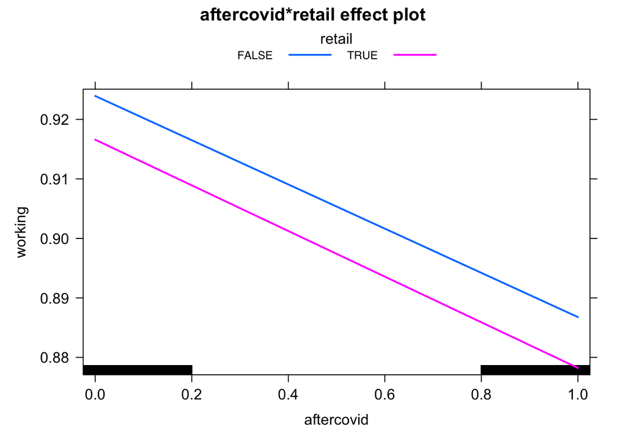

```r
model5effect <- effect('aftercovid*retail', model5, se= TRUE)
plot(model5effect, multiline = TRUE)
```

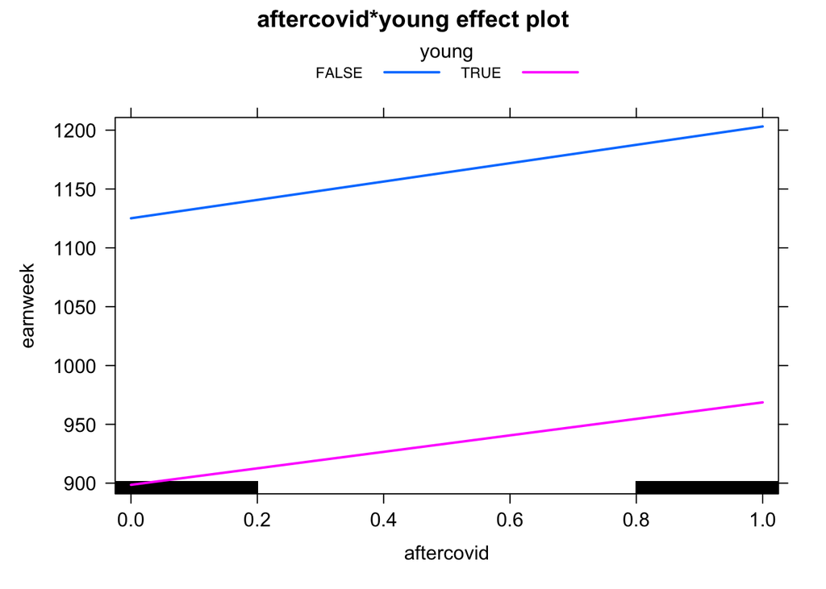

```r
model6youngbinaryeffect <- effect('aftercovid*young', model6, se= TRUE)
plot(model6youngbinaryeffect, multiline = TRUE)
```

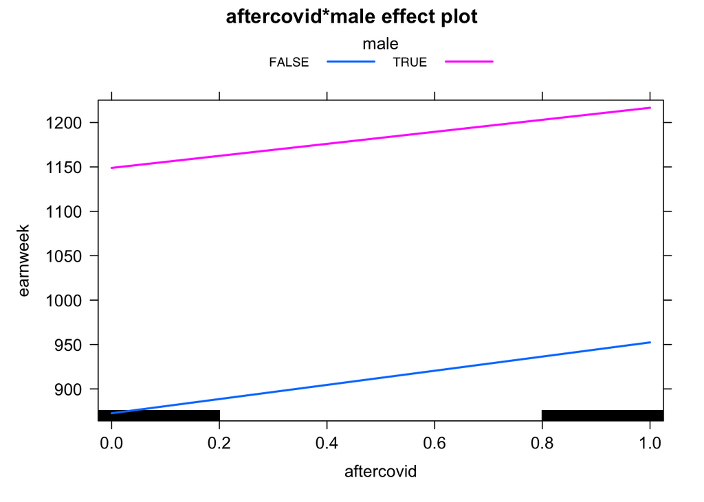

```r
model7effect <- effect('aftercovid*male', model7, se= TRUE)
plot(model7effect, multiline = TRUE)
```

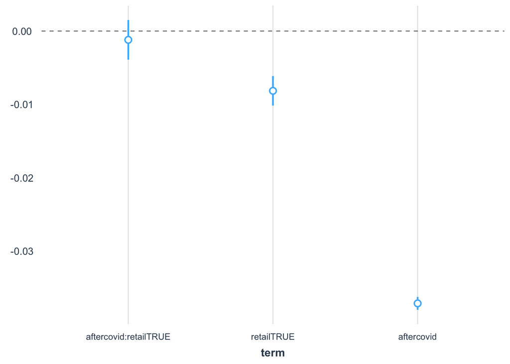

```r
plot_coefs(model2, scales = "fixed", level = 0.025) + coord_flip()
```

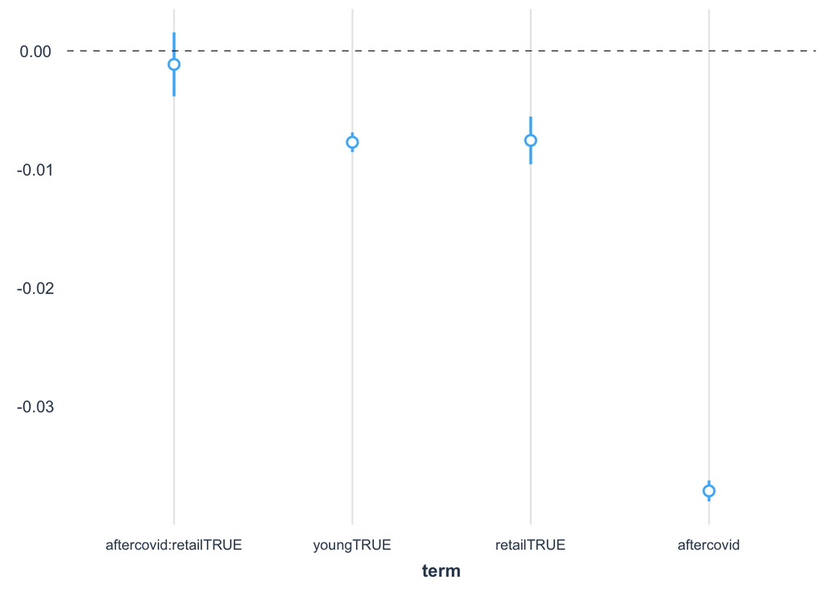

```r
plot_coefs(model3, scales = "fixed", level = 0.025) + coord_flip()
```

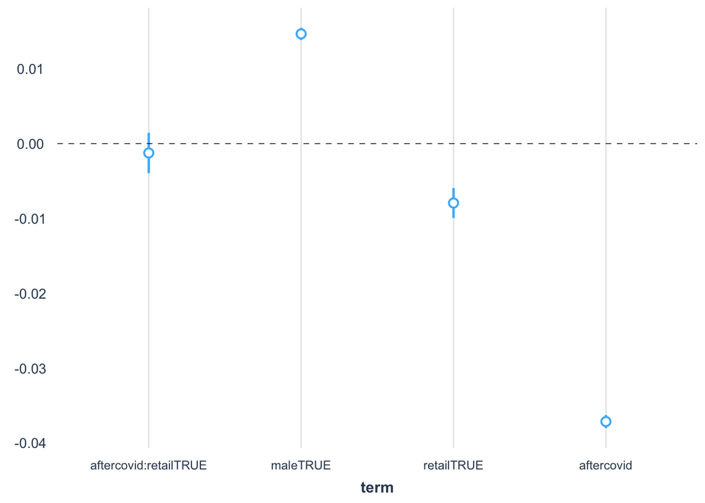

```r
plot_coefs(model4, scales = "fixed", level = 0.025) + coord_flip()
```

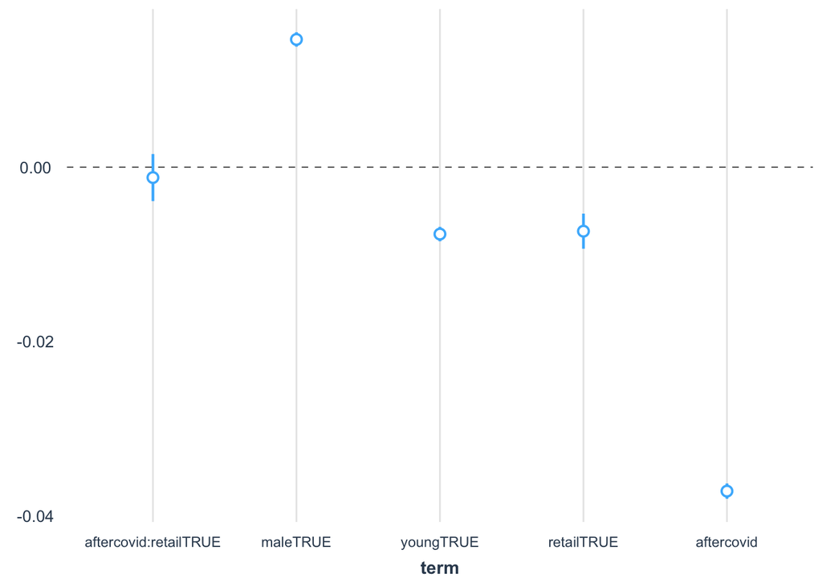

```r
plot_coefs(model5, scales = "fixed", level = 0.025) + coord_flip()
```

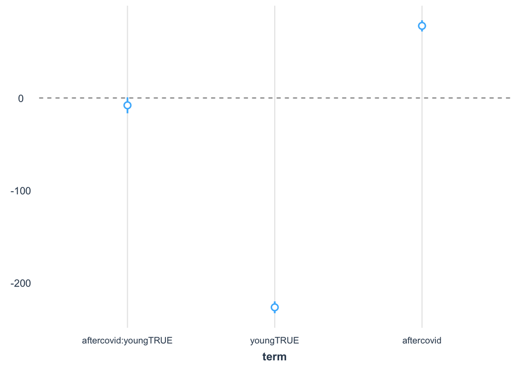

```r
plot_coefs(model6, scales = "fixed", level = 0.025) + coord_flip()
```

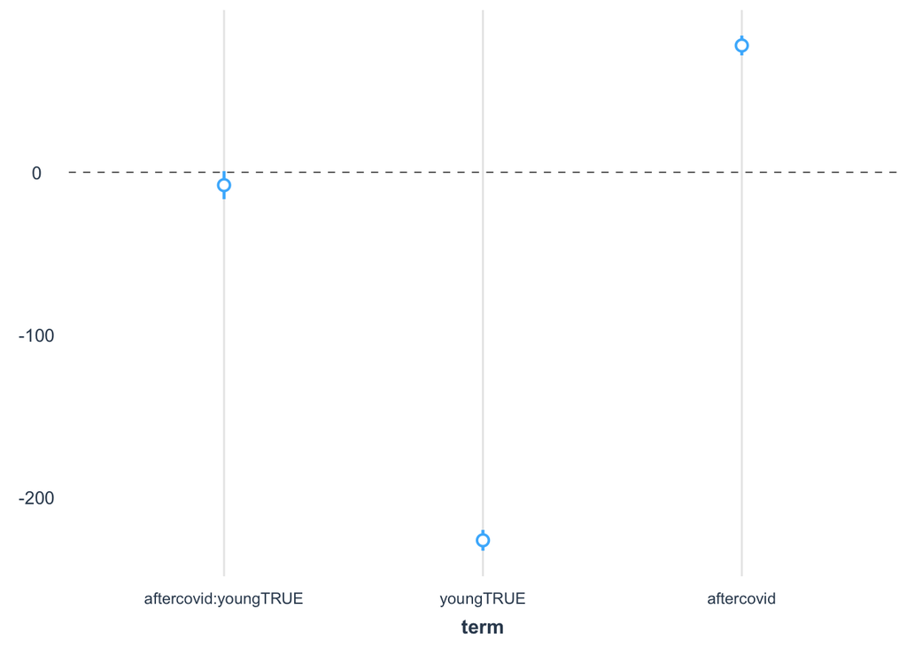

```r
plot_coefs(model6youngbinary, scales = "fixed", level = 0.025) + coord_flip()
```

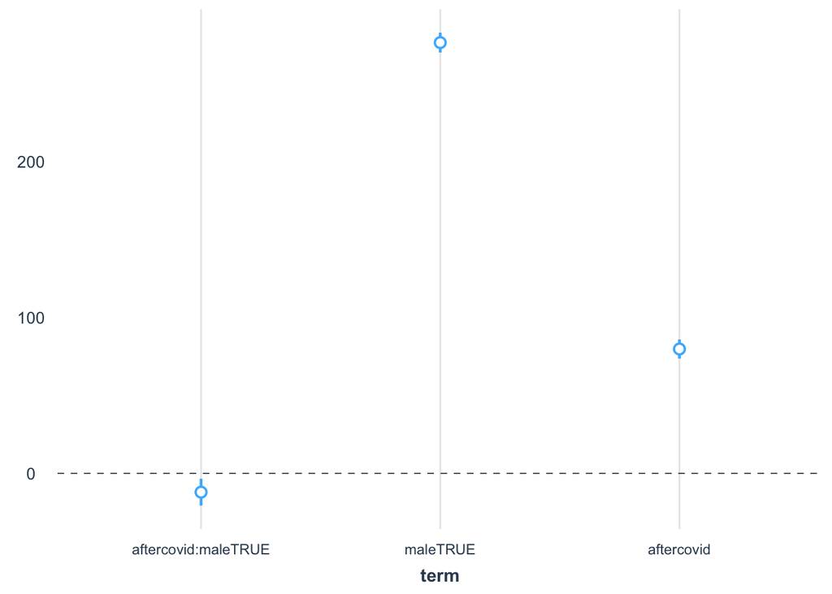

```r
plot_coefs(model7, scales = "fixed", level = 0.025) + coord_flip()
```

Above we plot our models to visually see the effects we’re trying to understand through our models. In addition, we include confidence interval plots to accompany the effect graphs.

*Write-up*

Question 1:How has COVID affected the health of the retail industry, as measured by employment?

We chose to run both a standard regression model and a modified feols DiD regression on the “working” variable, which measures if you are currently working against our “aftercovid” and “retail” variables; “aftercovid” is a binary variable that is true if the date is after March 1, 2020 and the “retail” variable is also a binary variable that indicates whether in a observation is from the retail industry or other industries. We chose to do both since they can give us two different interpretations of the same answer; however, we chose to go with the answer we got from the standard linear regression model since it better answers this particular question.

The above analysis answers our question by giving us an output which tells us the difference between the unemployment in the retail sector before Covid and after Covid.

We got a coefficient of -0.03711695 for aftercovid. This means that the impact of Covid on all industries regardless was negative as shown by this coefficient. We also had a coefficient of -0.00119868 for aftercovid:retailTRUE which tells us how much more the retail sector was impacted by Covid as measured by employment trends. When we add -0.03711695 and -0.00119868 together, we get the full impact of -0.03831563 that Covid had on employment in the retail sector. We had an intercept of 0.92399642, meaning this was the health of all industries before Covid-19. This gives us some context of how large the impact of Covid was on the retail sector.

One of the assumptions we are making here is that employment data is a good indicator for the health of a particular industry. We don’t actually know for a fact that just because fewer people are employed in a specific industry that the industry is suffering as a whole. Other factors such as automation and robotics come to mind when one thinks about lower employment but an increase in productivity in a particular industry.

After looking at all the analysis above, it’s fair to say that the retail industry saw a fairly sharp decline in employment numbers since the outbreak of Covid-19, meaning that the pandemic had a strong, negative impact on the health of the retail sector (as measured by employment).

Question 2: How has retail fared relative to other industries?

For this question we used the previous two models to find the answer to how retail fared compared to other industries. Through the interaction term of aftercovid*retail, these models give us insight into how employment trends in the retail industry changed, which helps us compare retail to other industries.

If we were to take the partial derivative of the model 2 with respect to aftercovid we would get the effect of B1(aftercovid) + B3(retailTRUE). This tells us that the effect of Covid on the employment trends in other industries is simply the B1 coefficient, and to get the additional impact of Covid in the retail industry specifically, we look at the B3 coefficient. Model 1 shows us the interaction term aftercovid:retailFALSE which demonstrates the impact of Covid but in the opposite direction (i.e., the output shows the impact of Covid on employment in non-retail industries).

Additionally, we assume here that we don’t have identification error. While we are stating that because of Covid, industries (especially retail) were negatively affected by the pandemic, do we really know that this is the true theoretical conclusion to reach by looking at the relationship between the variables in our data? There might be other explanations for this relationship. For example, access to educational resources became easier in recent years, so more and more people are developing skills that are in demand, and therefore, we notice a gradual decrease in employment in the retail industry, where there are not many highly demanded skills.

Question 3: Retail needs to worry about who has money to spend - what has changed about who is working and earning money?

We run two regression models that show the difference in earnings by sex and by age before and after Covid, as we need to know who is making good earnings, as those people represent who has the ability to spend. In running the regression, we could see if younger or older people own more money, and whether male or female workers earn more.

In answering the question, we need information about which types of people in society have more earnings, specifically focusing on the age and sex of workers, as the variables include a large number of workers within society. The result shows that old people are earning more than young people and male workers are earning more money than female workers.

If we want to take the partial derivative of model 6 concerning aftercovid, we will get the effect of B1(aftercovid) + B3(youngTRUE). It tells us the impact of Covid on earning between the group of young and older people. Also, the exact partial derivative for model 7 would be B1(aftercovid) + B3(MaleTrue) to demonstrate the effect by sex.

Model 7 shows the coefficient of 276.35 for maleTrue, indicating that male workers earn more than female workers. As we move to our model for aftercovid:MaleTrue, we receive a coefficient of -12.06, illustrating that the earnings of male workers were comparatively more negatively affected after Covid. However, the gap of earning between male and female workers is so large before covid, so our plot would show that male workers are earning more than female workers in general.

We choose sex and age as the assumptions of the analysis because both categories would cover all the people within the society, and most retail stores have their own target consumers based on age and sex. We could have evidence showing that old people usually have more salaries as they are the old employers of companies and normally receive higher salaries based on their experiences, and male workers earn higher than female ones could be due to sexism, as it is the problem that still exists in the labor market.

Additionally, one assumption that we are making is about identifying who earns more money between groups of people from age to sex, as certain products in the retail stores would have target consumers based on identities. While using the two models, we could identify which groups of people are receiving more and plan on doing marketing strategies with people who have money.

In addition to supporting our assumptions about our data, society itself is evidence of showing the same results toward earnings. Since older people are more talented and experienced, they are usually the people who earn more, and we believe that there are no companies who do not like employers with a strong background. And for males and females, the society has news about male workers earning more in general than females, which is the same result that we have received from model 7. Though the pandemic shifts a little bit for female workers on earning, the gap is too large between the two sex, making the plot of earning on sex with a significant gap in between.

In conclusion, we could see that older people and male workers have the most earnings, so they are the people who are earning the most. Also, we see a shift in female workers as they have a higher effect after pandemic on earnings, which is a result to be considered in the retail stores.